# PCB 6456 EXAM 2 - GLMs

**Background** The data file “Fish_parasites.csv” contains data for the number of parasites counted on fish that were sampled from a creek at 20 sites located at different distances from cooling towers of a nuclear power plant. The goal of the study was to determine if the elevated temperatures from cooling tower effluent affected parasite prevalence and virulence in fish. Although it was not part of the original sampling design, the researchers discovered that there was an additional and potentially confounding variable that differred among sites–salinity. The researchers noted the salinity of each site in their data file by classifying each site as being either high or low salinity.

**Specific Question** Determine whether the abundance of parasites increases with distance from power plants and to what extent does salinity influence those effects.

```r
fish<-read.csv("~/GitHub/Fish_parasites.csv", stringsAsFactors = FALSE)
head(fish)
```

|  | salinity | counts | distance |
| --- | --- | --- | --- |
| 1 | hi | 3 | 20.6165565 |
| 2 | hi | 5 | 4.4771877 |
| 3 | hi | 1 | 2.1158959 |
| 4 | hi | 2 | 74.7009169 |
| 5 | hi | 9 | 27.2261224 |
| 6 | hi | 1 | 0.3793085 |

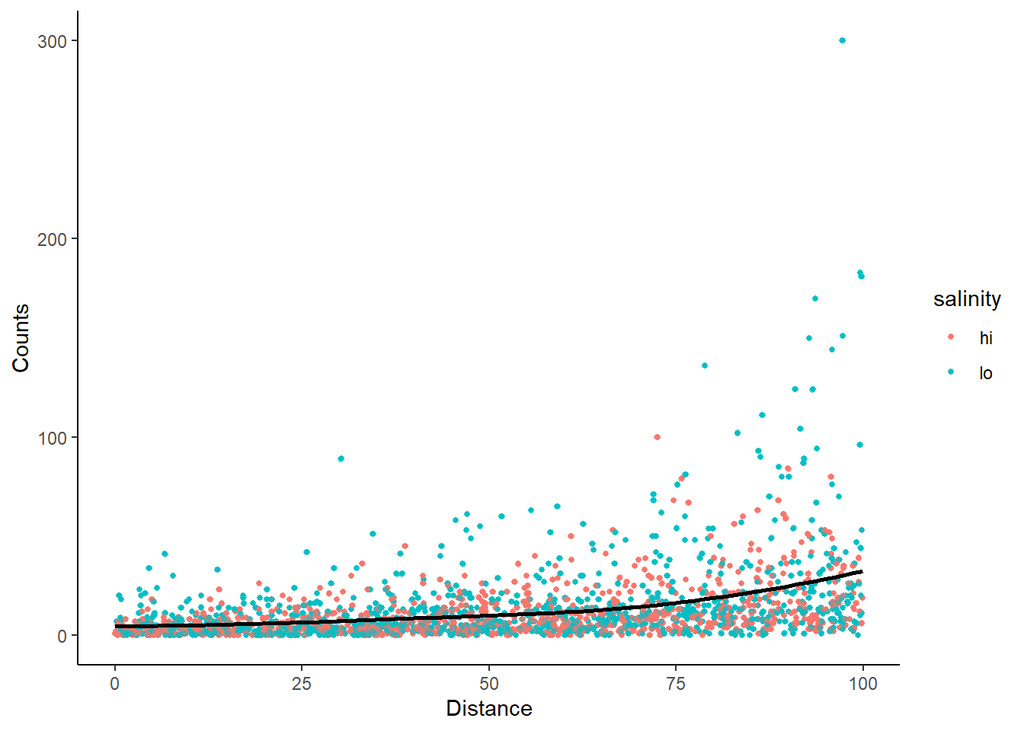

```r
library(ggplot2)
ggplot(fish, aes(x = distance, y = counts, colour = salinity)) +
    geom_point(size = 1) +
    labs(x = "Distance", y = "Counts") +
    theme_classic()+geom_jitter(size=1,height=.1,width=0.1,alpha=0.5)+
geom_smooth(method = "loess", size = 1, col = "black", se = FALSE) + labs(x = "Distance", y = "Counts") +  theme_classic()
```

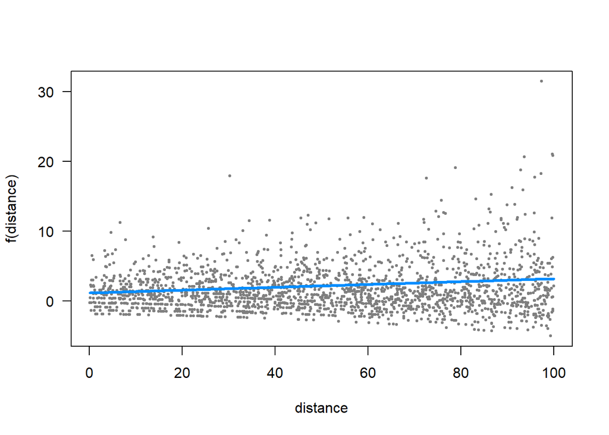

```r
cat<- glm(counts ~ distance+salinity, family = poisson(link = "log"), data = fish)


visreg(cat, xvar = "distance")
```

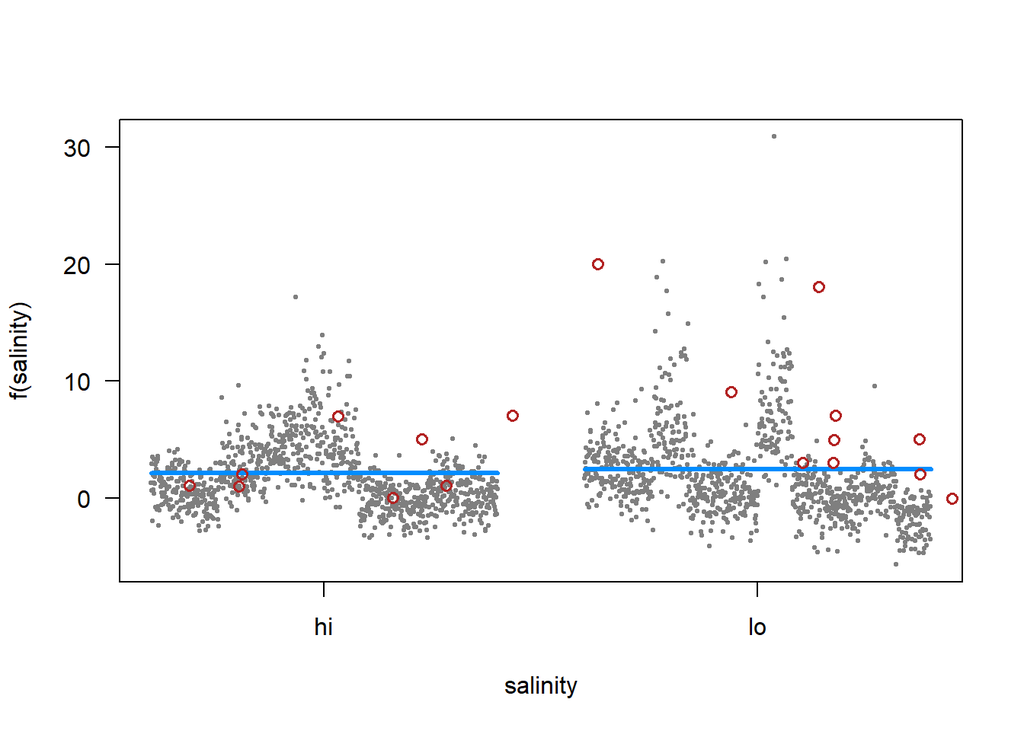

```r
visreg(cat, xvar = "salinity", rug = FALSE); points(jitter(counts, 0.2) ~ distance, data = fish, pch = 1,
    col = "firebrick", lwd = 1.5)
```